# Lab Assignment #3 - Sample Solution

Heike Hofmann

# Lab #3: Spreadsheeting the joy

[figure not shown]

## Selfefficacy measures and pitfalls

Two Excel spreadsheets are available for our lab today: FileOne and FileTwo.

1. Download the files and save them in a folder called “Spreadsheets”. Place that folder into the same folder as your Rmd file for the lab report.
2. The two files are two different measures of self efficacy of the same students. Each of the Excel files consist of four sheets, one for each semester between Spring 2011 and Fall 2012. In each semester, a score of a pre- and a post-test is recorded, together with some demographic information (gender and Characteristic).
3. The two Excel files track scores from two different tests for the same students (same id (in first column) means the same student).

## Goals of the lab

The big goal for this lab is to come up with a single data set consisting of (type of) measure, semester, student id, student demographics, and pre- and post-test score.

The lab report is supposed to document all steps you take from reading the data out of the Excel spread sheets to checking data quality to the final data.

Document in the report

## Two routes of solutions

- `rbind` all files:
- leads to long form of data
- no problems with combining data
- BUT: did you find all of the problems in the data?
- combination of `rbind` and `join`:
- leads to a wider variant of the data
- might not be straightforward, because of problems in the data
- no problem identifying the data problems

# Data problems you were supposed to find

- ids are not the same between `FileOne` and `FileTwo`
- some id don’t describe the same person:
- gender is different
- Characteristic is different

## Reading files into two big files

```r
readSheet <- function(file, sheet) {
# read the data in the sheets
  xls <- readxl::read_excel(file, sheet=sheet)
  names(xls)[1:2] <- c("StudentID", "Test")
  names(xls) <- trimws(names(xls))
  xls$file <- file
  xls$sheet <- sheet
  xls %>% select(file, sheet, StudentID, Test, Total, GENDER, Characteristic, `Treatment Part 1`, `Treatment Part 2`)
}

xl11 <- readSheet("Spreadsheets/FileOne.xlsx", sheet=1)
xl12 <- readSheet("Spreadsheets/FileOne.xlsx", sheet=2)
xl13 <- readSheet("Spreadsheets/FileOne.xlsx", sheet=3)
xl14 <- readSheet("Spreadsheets/FileOne.xlsx", sheet=4)
xl21 <- readSheet("Spreadsheets/FileTwo.xlsx", sheet=1)
xl22 <- readSheet("Spreadsheets/FileTwo.xlsx", sheet=2)
xl23 <- readSheet("Spreadsheets/FileTwo.xlsx", sheet=3)
xl24 <- readSheet("Spreadsheets/FileTwo.xlsx", sheet=4)

xl1 <- rbind(xl11, xl12, xl13, xl14)
xl2 <- rbind(xl21, xl22, xl23, xl24)
```

## Data cleaning

Separate the data into two parts:

```r
cleanSheet <- function(data) {
  # separate data into pre and post,
  # rename total to pre and post
  # merge post into pre
  pre <- data %>% filter(tolower(Test) == "pre") %>%
    mutate(pre = Total) %>% select(-Total, -Test)
  post <- data %>% filter(tolower(Test) == "post") %>%
    mutate(post = Total) %>% select(StudentID, post)
  aj <- anti_join(pre, post, by="StudentID")
  stopifnot(nrow(aj)==0) # needs a better error message

  left_join(pre, post, by="StudentID")
}

xl1clean <- cleanSheet(xl1)
xl2clean <- cleanSheet(xl2)
```

# Route #1: one big skinny file

## Combine Datasets

```r
xls <- rbind(xl1clean, xl2clean) %>%
  mutate(
    GENDER = factor(GENDER),
    Characteristic = factor(Characteristic),
    TR1 = factor(`Treatment Part 1`), # rename just for convience
    TR2 = factor(`Treatment Part 2`)
  ) %>% select(-`Treatment Part 1`, - `Treatment Part 2`)
summary(xls)
```

```
##      file               sheet         StudentID          GENDER
##  Length:360         Min.   :1.000   Min.   :    1.0   Female:189
##  Class :character   1st Qu.:1.000   1st Qu.:   61.5   Male  :161
##  Mode  :character   Median :2.000   Median :20060.0   NA's  : 10
##                     Mean   :2.431   Mean   :21848.8
##                     3rd Qu.:3.000   3rd Qu.:30043.2
##                     Max.   :4.000   Max.   :41138.0
##  Characteristic      pre              post        TR1         TR2
##  No  :224       Min.   : 21.00   Min.   : 21.00   NR:191   LP   :266
##  Yes :130       1st Qu.: 67.75   1st Qu.: 66.00   R :169   No LP: 94
##  NA's:  6       Median : 92.00   Median : 92.50
##                 Mean   : 91.07   Mean   : 91.99
##                 3rd Qu.:117.00   3rd Qu.:120.00
##                 Max.   :143.00   Max.   :156.00
```

```r
xls %>% filter(is.na(GENDER))
```

```
## # A tibble: 10 × 9
##                         file sheet StudentID GENDER Characteristic   pre
##                        <chr> <dbl>     <dbl> <fctr>         <fctr> <dbl>
## 1  Spreadsheets/FileOne.xlsx     2     20055     NA             No    70
## 2  Spreadsheets/FileOne.xlsx     3     30039     NA             NA    76
## 3  Spreadsheets/FileOne.xlsx     4     40109     NA             No    72
## 4  Spreadsheets/FileOne.xlsx     4     40116     NA             No    80
## 5  Spreadsheets/FileOne.xlsx     4     40120     NA             No    21
## 6  Spreadsheets/FileTwo.xlsx     3     30035     NA             NA   130
## 7  Spreadsheets/FileTwo.xlsx     3     30038     NA             NA    90
## 8  Spreadsheets/FileTwo.xlsx     4     41109     NA             No   118
## 9  Spreadsheets/FileTwo.xlsx     4     41117     NA             NA   140
## 10 Spreadsheets/FileTwo.xlsx     4     41121     NA             NA   113
## # ... with 3 more variables: post <dbl>, TR1 <fctr>, TR2 <fctr>
```

## Inconsistencies

All students should show up twice in the data (once in FileOne, once in FileTwo):

```r
xls %>% count(StudentID) %>% filter(n != 2)
```

```
## # A tibble: 82 × 2
##    StudentID     n
##        <dbl> <int>
## 1      20033     1
## 2      20035     1
## 3      20038     1
## 4      20063     1
## 5      30019     1
## 6      30024     1
## 7      30051     1
## 8      40101     1
## 9      40102     1
## 10     40103     1
## # ... with 72 more rows
```

```r
xls %>% filter(StudentID == 20033)
```

```
## # A tibble: 1 × 9
##                        file sheet StudentID GENDER Characteristic   pre
##                       <chr> <dbl>     <dbl> <fctr>         <fctr> <dbl>
## 1 Spreadsheets/FileOne.xlsx     2     20033 Female            Yes    78
## # ... with 3 more variables: post <dbl>, TR1 <fctr>, TR2 <fctr>
```

All students should have one gender:

```r
xls %>% group_by(StudentID) %>% summarize(n = length(unique(GENDER))) %>% filter(n != 1)
```

```
## # A tibble: 14 × 2
##    StudentID     n
##        <dbl> <int>
## 1      20055     2
## 2      30026     2
## 3      30028     2
## 4      30029     2
## 5      30030     2
## 6      30034     2
## 7      30035     2
## 8      30038     2
## 9      30039     2
## 10     30042     2
## 11     30044     2
## 12     30045     2
## 13     30047     2
## 14     30050     2
```

```r
xls %>% filter(StudentID == 30026)
```

```
## # A tibble: 2 × 9
##                        file sheet StudentID GENDER Characteristic   pre
##                       <chr> <dbl>     <dbl> <fctr>         <fctr> <dbl>
## 1 Spreadsheets/FileOne.xlsx     3     30026   Male            Yes    89
## 2 Spreadsheets/FileTwo.xlsx     3     30026 Female             No   102
## # ... with 3 more variables: post <dbl>, TR1 <fctr>, TR2 <fctr>
```

The characteristic should not change for each student:

```r
xls %>% group_by(StudentID) %>% summarize(n = length(unique(Characteristic))) %>% filter(n != 1)
```

```
## # A tibble: 17 × 2
##    StudentID     n
##        <dbl> <int>
## 1      30026     2
## 2      30028     2
## 3      30030     2
## 4      30033     2
## 5      30035     2
## 6      30036     2
## 7      30038     2
## 8      30039     2
## 9      30040     2
## 10     30041     2
## 11     30042     2
## 12     30044     2
## 13     30045     2
## 14     30046     2
## 15     30047     2
## 16     30048     2
## 17     30050     2
```

```r
xls %>% filter(StudentID == 30028)
```

```
## # A tibble: 2 × 9
##                        file sheet StudentID GENDER Characteristic   pre
##                       <chr> <dbl>     <dbl> <fctr>         <fctr> <dbl>
## 1 Spreadsheets/FileOne.xlsx     3     30028 Female             No    70
## 2 Spreadsheets/FileTwo.xlsx     3     30028   Male            Yes   126
## # ... with 3 more variables: post <dbl>, TR1 <fctr>, TR2 <fctr>
```

## Spreading the data

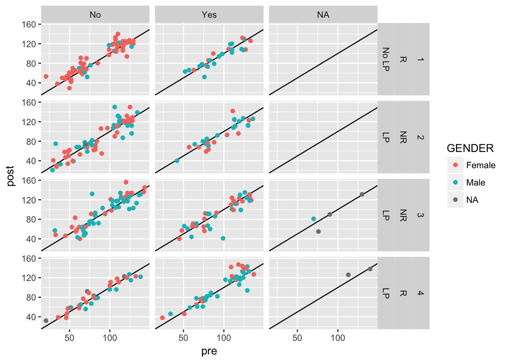

```r
xls %>% ggplot(aes(pre, post)) + geom_abline()+
  geom_point(aes(colour = GENDER)) +
  facet_grid(sheet+TR1+TR2~Characteristic)
```

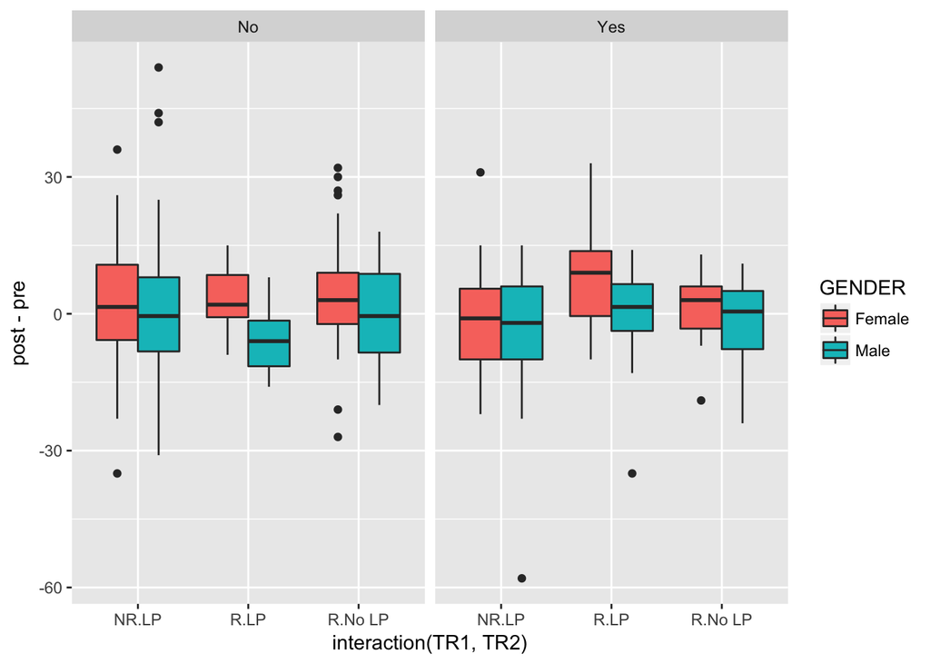

```r
xls %>% filter(!is.na(Characteristic), !is.na(GENDER)) %>%
  ggplot(aes(interaction(TR1, TR2), post-pre)) +
  geom_boxplot(aes(fill = GENDER)) +
  facet_grid(.~Characteristic)
```

# Route #2: `rbind` and `join`

```r
aj1 <- anti_join(xl1clean, xl2clean, by="StudentID")
aj2 <- anti_join(xl2clean, xl1clean, by="StudentID")
# these are the ones we cannot match:
dim(aj1)
```

```
## [1] 40  9
```

```r
dim(aj2)
```

```
## [1] 42  9
```

```r
xlwide <- full_join(xl1clean, xl2clean, by="StudentID")
```

Mainly a problem of 40 versus 41 at the beginning of the StudentID.

`Gender.x` should be the same as `Gender.y`:

```r
summary(xlwide$GENDER.x != xlwide$GENDER.y)
```

```
##    Mode   FALSE    TRUE    NA's
## logical     125      10      86
```

`Characteristic.x` should be the same as `Characteristic.y`:

```r
summary(xlwide$Characteristic.x != xlwide$Characteristic.y)
```

```
##    Mode   FALSE    TRUE    NA's
## logical     122      13      86
```